# Funafuti — The Tuvalu Threshold

# What Sits in the Difference

FUNAFUTI, TUVALU · SEA-LEVEL RISE (SLR) THRESHOLDS

[figure not shown]

For Tuvalu, the difference between 1°C and 1.5°C of warming is not a number — it’s the island.

On Funafuti, home to most of Tuvalu’s people, the largest open space is the airport runway. Most evenings, when no flight is due, it fills with football, cycling, and families in the cooling air, because on an atoll this narrow there is nowhere else with room.

It is the widest flat ground on the island, and it rises only a few meters above the water — ocean on one side, the lagoon on the other. Half a degree of warming sounds incremental; on ground this low, it can become geographic.

The scenarios below are illustrative thresholds, not precise projections. See the methodology for assumptions and limitations.

Those thresholds are scenarios. The trend beneath them is not. Around Tuvalu, sea-surface temperatures have climbed out of more than a century of cooler readings.

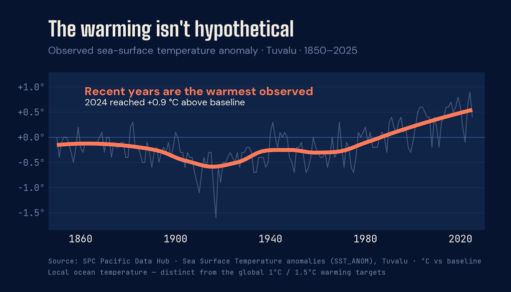

A warmer ocean is a higher one — expanding as it heats, and fed by ice melting far away. What that added height would mean for ground this low is the question the next three maps put to the atoll itself.

Funafuti is not a block of land. It is a thin ring of motu around a lagoon — narrow, fragmented, and already close to the ocean.

Look at the width of the land. In many places, the reef strips are narrower than a city block.

At one meter of sea-level rise, the edges begin to fail first. The exposed land is still measured in single digits — but the pattern has changed.

The step from one meter to one and a half meters is roughly comparable to the difference between 1°C and 1.5°C of global warming.

By 1.5 meters, the story is no longer just edge loss. The connecting strips between motu begin to fragment — and exposure nearly doubles.

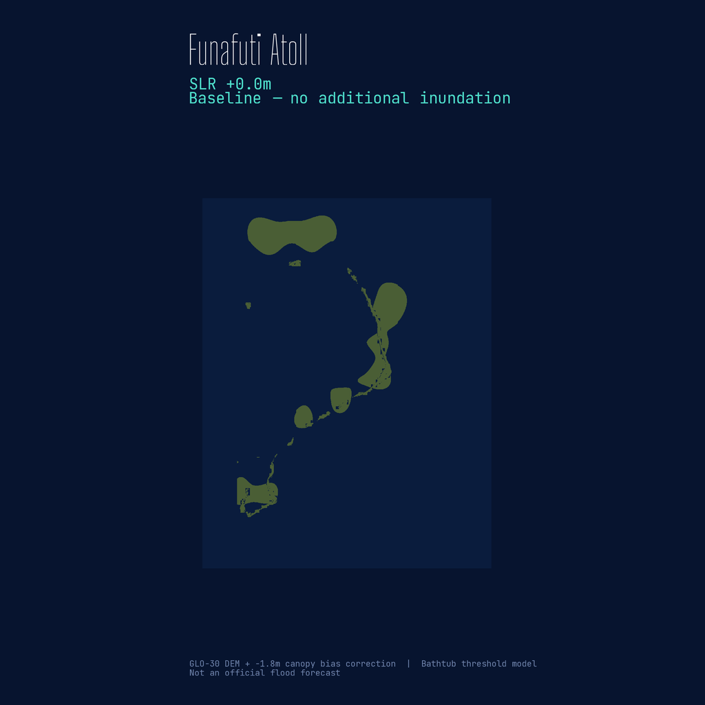

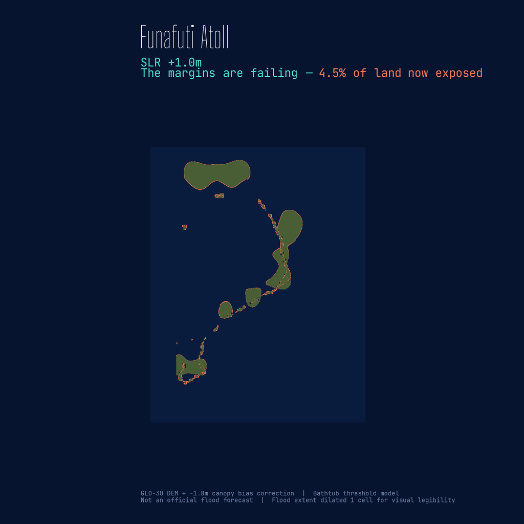

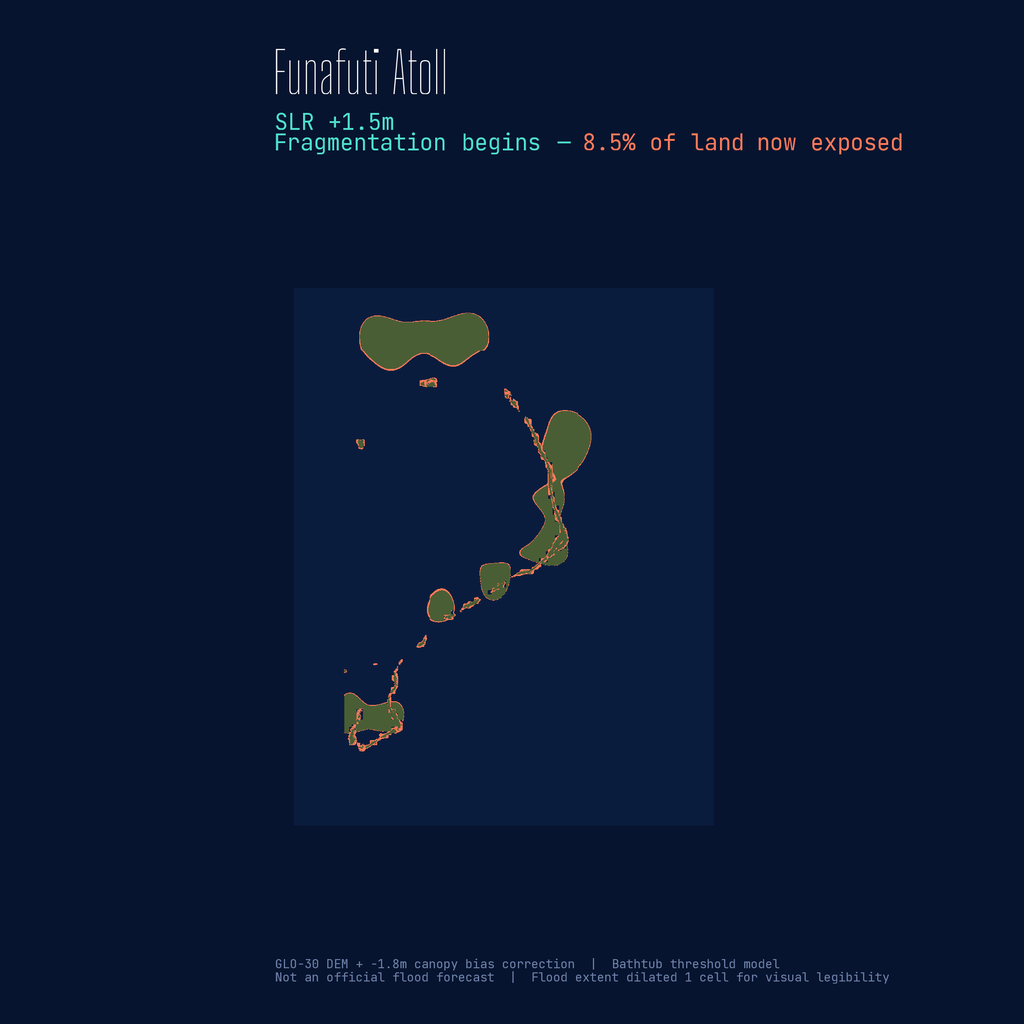

## The Numbers Behind the Maps

The maps show where. This chart shows how much more. Between 1.0m and 1.5m of rise, the exposed share of Funafuti’s land nearly doubles.

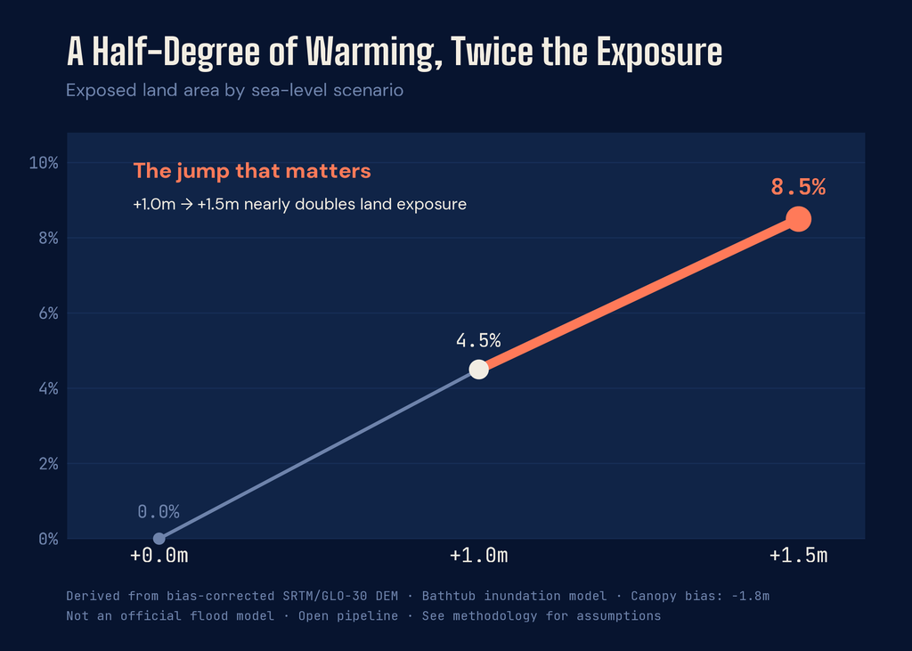

The distance between these scenarios is half a degree. It sounds small. On an atoll this narrow, it becomes geography.

The maps do not show a fate sealed. They show one still open.

Tuvalu is what sits in the difference.

## Methodology

Flood extents were derived using a bathtub inundation model — any land pixel with corrected elevation at or below the sea-level rise threshold is classified as exposed. The bathtub model assumes static, connected inundation and does not account for wave dynamics, storm surge, groundwater intrusion, or sediment transport. It represents a low-elevation exposure threshold, not a flood prediction. Flood pixels in the rendered maps are expanded by one grid cell outward for visual legibility; the percentage figures in the subtitles reflect the methodologically correct threshold without this display expansion.

Three scenarios are shown: 0.0m (current baseline), 1.0m, and 1.5m of sea-level rise. The relationship between global mean temperature and sea-level rise is nonlinear and scenario-dependent; the 1.0m and 1.5m scenarios are used here as illustrative thresholds, not as precise projections for specific warming levels.

The sea-surface temperatures shown here are local anomalies around Tuvalu, measured relative to the dataset’s reference baseline, and should not be read as the global 1°C and 1.5°C warming thresholds referenced elsewhere in this piece.

Coastline geometry is sourced from OpenStreetMap via the `osmextract` package. All analysis was conducted in R using the `terra` and `sf` spatial packages. Maps were rendered with `ggplot2` and `tidyterra`. The full pipeline is open and reproducible.

DATA SOURCES

- AWS Open Data Terrain Tiles (composite global elevation model from open sources), accessed via the `elevatr` R package. Open data.
- OpenStreetMap coastline geometry, via `osmextract` / Geofabrik. © OpenStreetMap contributors, ODbL 1.0.
- Derived flood-exposure scenarios at 0.0m, 1.0m, and 1.5m sea-level rise, produced by the author using the bathtub inundation model described above.
- Atoll canopy-height correction informed by Yamano et al. (2007) and Tuck et al. (2019).
- Sea Surface Temperature anomalies (`ST_ANOM`, °C), Tuvalu, 1850–2025. [Pacific Community (SPC) Pacific Data Hub .Stat](https://stats.pacificdata.org/vis?lc=en&df[ds]=SPC2&df[id]=DF_CLIMATE_CHANGE&df[ag]=SPC&df[vs]=1.0&av=true&dq=A.ST_ANOM.&pd=,&to[TIME_PERIOD]=false), Climate Change Indicators.
- Sea Level Anomalies (`SEA_LVL`, m), Tuvalu, 1993–2023. [Pacific Community (SPC) Pacific Data Hub .Stat](https://stats.pacificdata.org/vis?lc=en&df[ds]=SPC2&df[id]=DF_CLIMATE_CHANGE&df[ag]=SPC&df[vs]=1.0&av=true&dq=A.SEA_LVL.&pd=,&to[TIME_PERIOD]=false), Climate Change Indicators.

TOOLS

R · Quarto · Closeread v1.0.1 · ggplot2 · ggtext · showtext · terra · sf · tidyterra · elevatr · osmextract · patchwork

NOT AN OFFICIAL FLOOD FORECAST · OPEN PIPELINE · REPRODUCIBLE IN R

LICENCE

This work — code, narrative, and derived visualisations — is licensed under [CC BY 4.0](https://creativecommons.org/licenses/by/4.0/). You are free to share and adapt with attribution. OpenStreetMap-derived geometry remains under [ODbL 1.0](https://opendatacommons.org/licenses/odbl/); the elevation data are sourced from AWS Open Data Terrain Tiles via `elevatr`.

Steven Ponce · Data Analyst & R/Shiny Developer · Pacific Dataviz Challenge 2026

[LinkedIn](https://www.linkedin.com/in/stevenponce/) · [Bluesky](https://bsky.app/profile/sponce1.bsky.social) · [GitHub](https://github.com/poncest) · stevenponce.netlify.app